# Homework 7

Chris Boyd

3/18/2019

```r
library(tidyverse)
library(dplyr)
library(broom)
```

# Exercise 1

> Load the train.csv dataset into R. How many observations and columns are there?

```r
import_file_path = "../data/train.csv"
train_data <- read.csv(import_file_path, header = TRUE)
```

There are 1,460 observations and 81 variables.

# Exercise 2

> Visualize the distribution of SalePrice.

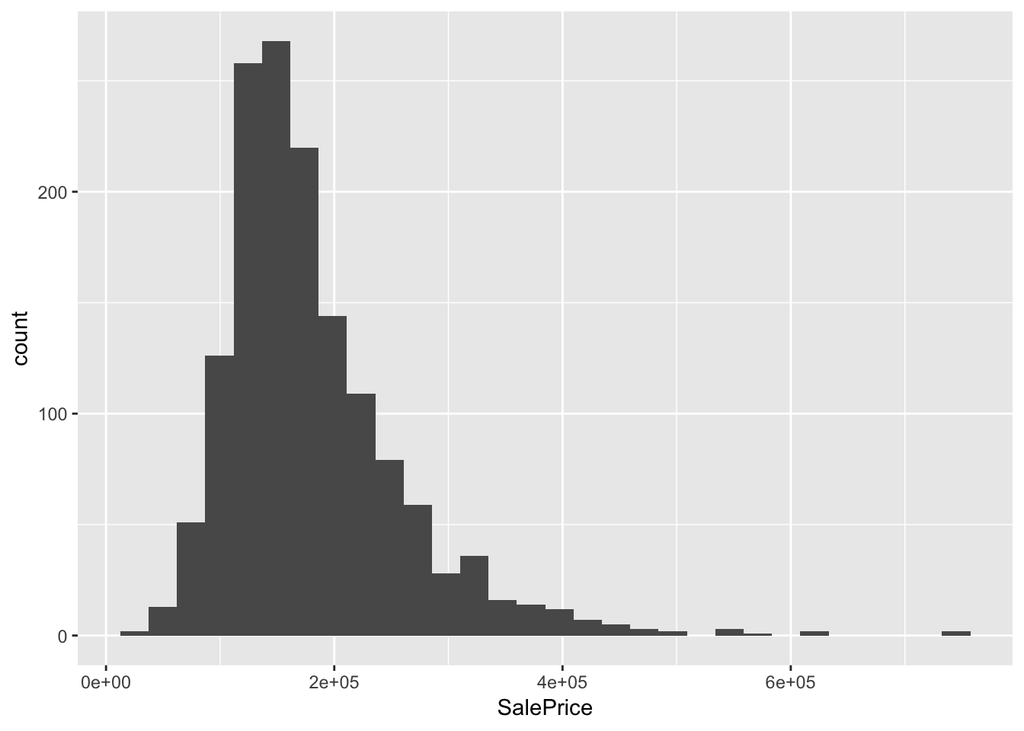

```r
train_data %>%
  ggplot(aes(x = SalePrice)) +
    geom_histogram()
```

> Visualize the covariation between SalePrice and Neighborhood.

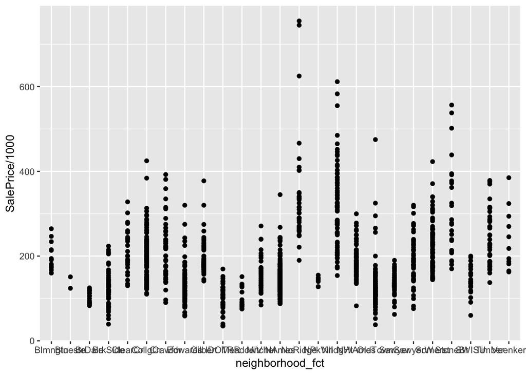

```r
train_data <- train_data %>% mutate(neighborhood_fct = factor (Neighborhood, ordered=FALSE))


train_data %>%
  ggplot(aes(x =neighborhood_fct , y= SalePrice/1000)) +
    geom_point() +
    geom_smooth(method='lm')
```

Can’t really visualize the covariance since Neighborhood is an unordered categorical variable.

> Visualize the covariation between SalePrice and OverallQual

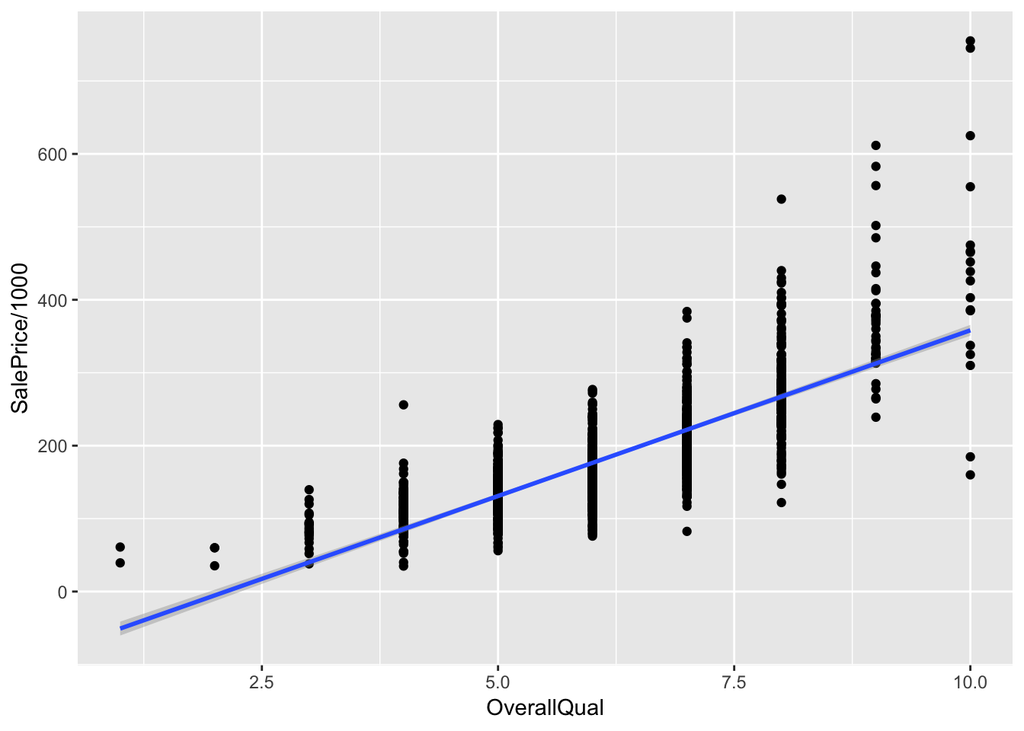

```r
train_data %>%
  ggplot(aes(x =OverallQual , y=SalePrice / 1000)) +
    geom_point() +
    geom_smooth(method='lm')
```

# Exercise 3

> Our target is called SalePrice. First, we can fit a simple regression model consisting of only the intercept (the average of SalePrice). Fit the model and then use the broom package to:

I don’t completely understand the question. Specifically not sure how to fit a simple regression to one variable. So, I used on OverallQual.

> take a look at the coefficient

```r
(diam_lm <- lm(formula = SalePrice ~ OverallQual, data = train_data))
```

```
##
## Call:
## lm(formula = SalePrice ~ OverallQual, data = train_data)
##
## Coefficients:
## (Intercept)  OverallQual
##      -96206        45436
```

[figure not shown]

> compare the coefficient to the average value of SalePrice, and

```r
glance(diam_lm)
```

```
## # A tibble: 1 x 11
##   r.squared adj.r.squared  sigma statistic   p.value    df  logLik    AIC
##       <dbl>         <dbl>  <dbl>     <dbl>     <dbl> <int>   <dbl>  <dbl>
## 1     0.626         0.625 48623.     2437. 2.19e-313     2 -17827. 35659.
## # … with 3 more variables: BIC <dbl>, deviance <dbl>, df.residual <int>
```

# Exercise 4

> Now fit a linear regression model using GrLivArea, OverallQual, and Neighborhood as the features. Don’t forget to look at data_description.txt to understand what these variables mean. Ask yourself these questions before fitting the model:

```r
diam_mult_lm <- lm(SalePrice ~ GrLivArea + OverallQual + Neighborhood, data = train_data)
tidy(diam_mult_lm)
```

```
## # A tibble: 27 x 5
##    term                estimate std.error statistic  p.value
##    <chr>                  <dbl>     <dbl>     <dbl>    <dbl>
##  1 (Intercept)         -34829.   11541.       -3.02 2.59e- 3
##  2 GrLivArea               55.6      2.50     22.2  2.38e-94
##  3 OverallQual          20951.    1162.       18.0  1.24e-65
##  4 NeighborhoodBlueste -30753.   27697.       -1.11 2.67e- 1
##  5 NeighborhoodBrDale  -43359.   12979.       -3.34 8.57e- 4
##  6 NeighborhoodBrkSide -13025.   10450.       -1.25 2.13e- 1
##  7 NeighborhoodClearCr  24576.   11570.        2.12 3.38e- 2
##  8 NeighborhoodCollgCr  11414.    9497.        1.20 2.30e- 1
##  9 NeighborhoodCrawfor  14444.   10502.        1.38 1.69e- 1
## 10 NeighborhoodEdwards -17843.    9986.       -1.79 7.42e- 2
## # … with 17 more rows
```

> What kind of relationship will these features have with our target?

Greating the living area, the higher the Sale Price. This will vary by Neighborhood.

```r
diam_mult_lm <- lm(SalePrice ~ GrLivArea + OverallQual + Neighborhood, data = train_data)
glance(diam_mult_lm)
```

```
## # A tibble: 1 x 11
##   r.squared adj.r.squared  sigma statistic p.value    df  logLik    AIC
##       <dbl>         <dbl>  <dbl>     <dbl>   <dbl> <int>   <dbl>  <dbl>
## 1     0.787         0.783 37009.      203.       0    27 -17416. 34887.
## # … with 3 more variables: BIC <dbl>, deviance <dbl>, df.residual <int>
```

> Can the relationship be estimated linearly?

Yes.

> Are these good features, given the problem we are trying to solve?

Yes.

> After fitting the model, output the coefficients and the R-squared using the broom package. Answer these questions:

> How would you interpret the coefficients on GrLivArea and OverallQual?

For every unit increase in GrLivArea, the price will increase $55, assuming all other features remain constant.

For every unit increase in OverallQual, price will increase by $21k, assuming all other features remain constant..

> How would you interpret the coefficient on NeighborhoodBrkSide?

> Are the features significant?

Yes.

> Are the features practically significant?

Yes. Tough, not sure what to make of the large std.error on the Neighborhoods.

> Is the model a good fit?

No. Adjusted R-squared is .78, which not that high.

# Exercise 6

> One downside of the linear model is that it is sensitive to unusual values because the distance incorporates a squared term. Fit a linear model to the simulated data below (use y as the target and x as the feature), and look at the resulting coefficients and R-squared. Rerun it about 5-6 times to generate different simulated datasets. What do you notice about the model’s coefficient on x and the R-squared values?

```r
sim1a <- tibble(
  x = rep(1:10, each = 3),
  y = x * 1.5 + 6 + rt(length(x), df = 2)
)

diam_mult_lm <- lm(y ~ x, data = sim1a)
glance(diam_mult_lm)
```

```
## # A tibble: 1 x 11
##   r.squared adj.r.squared sigma statistic p.value    df logLik   AIC   BIC
##       <dbl>         <dbl> <dbl>     <dbl>   <dbl> <int>  <dbl> <dbl> <dbl>
## 1     0.344         0.321  7.06      14.7 6.58e-4     2  -100.  206.  211.
## # … with 2 more variables: deviance <dbl>, df.residual <int>
```

```r
tidy(diam_mult_lm)
```

```
## # A tibble: 2 x 5
##   term        estimate std.error statistic  p.value
##   <chr>          <dbl>     <dbl>     <dbl>    <dbl>
## 1 (Intercept)     6.09     2.78       2.19 0.0372
## 2 x               1.72     0.449      3.83 0.000658
```

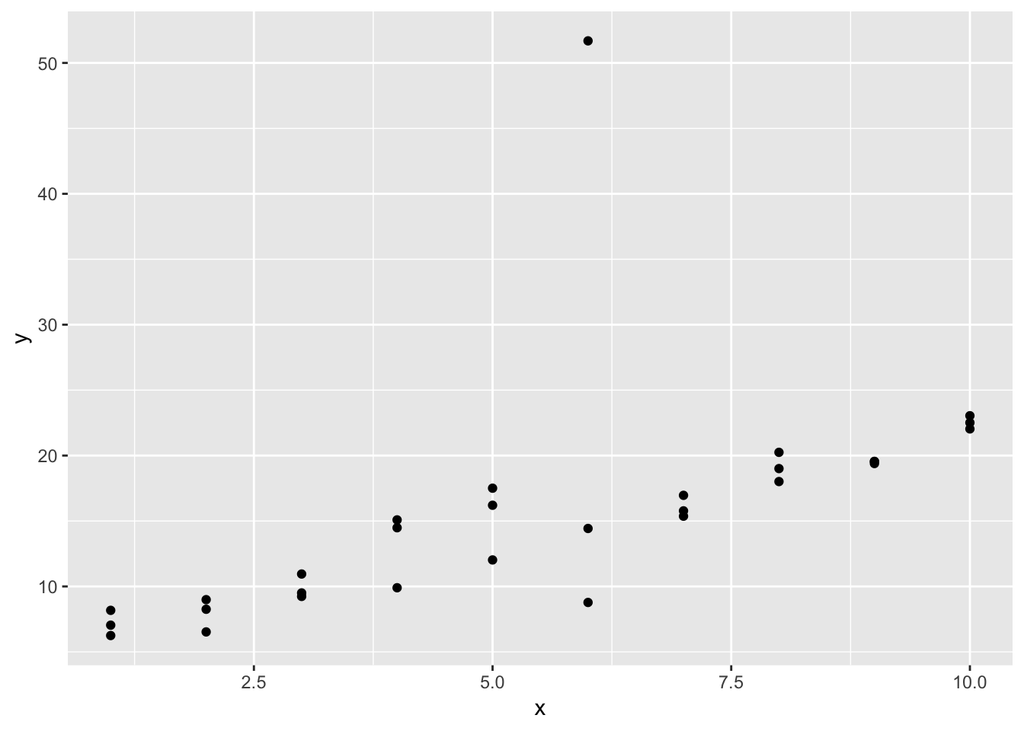

```r
sim1a %>%
  ggplot(aes(x =x , y=y)) +
    geom_point()
```

The model’s coefficient on x and the R-squared values change pretty signficantly as we re-run. I’ve seen a R-squared range between .7 and .9, with some as low as .2.

I’ve also seen the coefficient on X range between 1.2 and 1.8.